[figure not shown]

# Matplotlib

## Creating visuals from data

https://matplotlib.org/

# Learning Objectives

## Theory / Be able to explain ...

- The basic kinds of plots
- Matplotlib's 3 step plotting process
- How plots are decorated with various options
- The limitations of Matplotlib's 2D plotting model

## Skills / Know how to ...

- Create and display common types of plots
- Pass data and set options for each plot type
- Find your way around the documentation
- Use add-on libraries to enhance your plots

# Overview

## Making professional-quality plots from 2D arrays (standard Python, NumPy, Pandas)

# What's Matplotlib?

From the docs ...

> “Matplotlib is a library for making **2D plots of arrays in Python** … designed with the philosophy that **you should be able to create simple plots with just a few commands**, or just one! If you want to see a histogram of your data, you shouldn’t need to instantiate objects, call methods, set properties, and so on; **it should just work**.”

# Goal: Easy, Professional Plots

More from the docs …

> “Plots should look great - publication quality. One important requirement … is that the text looks good (antialiased, etc.)

> “Code should be easy enough that [anyone] can understand it and extend it.

> “Making plots should be easy.”

# Powerful and Flexible API

Input is 2D data in many possible formats:

- Lists, tuples, … arrays from NumPy or Pandas

Can produce a wide variety of plots:

- Line, Bar, Pie, and Scatter plots
- Histograms and Spectrograms
- Error plots, Box and Whisker plots, and Violin plots
- Polar plots and Hexagonal Binning ("heatmap") plots
- ...

# Standard Imports

The remaining slides assume that we have already imported NumPy, Pandas, and Matplotlib in the standard way. Note that we are just importing `matplotlib.pyplot` below. You can explore the rest of Matplotlib on your own time!

```python
import numpy as np
import pandas as pd
import matplotlib.pyplot as plt
```

# The `pyplot` module

## So, so much in a tiny package!

# Intuitive 3 Step Process

1. Make a new plot

   ```
   plt.hist(...)
   ```

2. Set a few options

   ```
   plt.xlabel('Smarts')
   ...
   ```

3. Display the plot

   ```
   plt.show()
   ```

[figure not shown]

# Note: Data is in Columns

`pyplot` generally assumes that data is passed as 1D sequences (lists, Pandas Series, NumPy arrays, etc.) If using DataFrames or other 2D arrays, then **slice column-wise to define x-coordinates and y-coordinates**.

# Line Chart

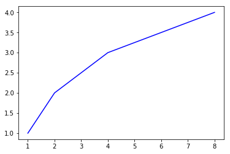

```python
# A basic 2D plot
plt.plot(
  [1,2,4,8], # x coords
  [1,2,3,4], # y coords
  "b-"       # blue (b) line (-)
)
plt.show()
```

# Simple Point Plot

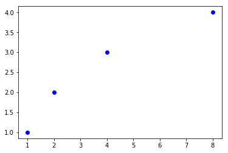

```python
# A basic 2D plot
plt.plot(
  [1,2,4,8], # x coords
  [1,2,3,4], # y coords
  "bo"       # blue (b) dots (o)
)
plt.show()
```

# Line Chart with Markers

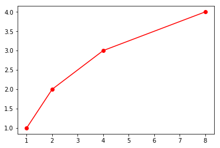

```python
# A basic 2D plot
plt.plot(
  [1,2,4,8], # x coords
  [1,2,3,4], # y coords
  "r-o"      # red (r) line (-) dots (o)
)
plt.show()
```

# Multiple Lines

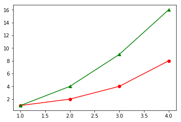

```python
plt.plot(
  [1,2,3,4],[1,2,4,8],"r-o", #series 1 with red lines and dots
  [1,2,3,4],[1,4,9,16],"g-^" # series 2 green lines and triangles
)
plt.show()
```

# Scatter Plot

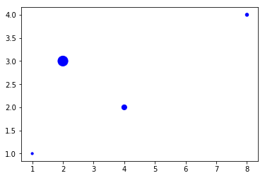

```python
plt.scatter(
  [1,4,2,8],       # x coords
  [1,2,3,4],       # y coords
  c='b',           # color
  s=[10,50,200,20] # sizes
)
plt.show()
```

# Bar Chart

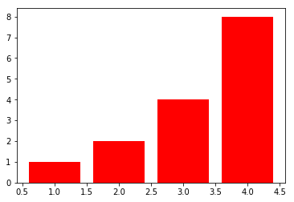

```python
plt.bar(
  [1,2,3,4], # x
  [1,2,4,8], # y
  color = "r"
)
plt.show()

# more options in the docs
```

# Pie Chart

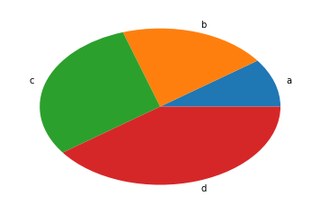

```python
plt.pie(
  [1,2,3,4], # x
  labels=['a','b','c','d'])
plt.show()
```

# Histogram

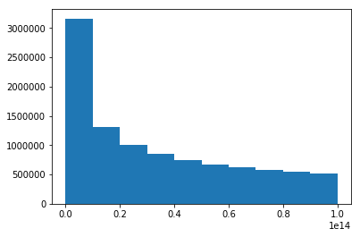

```python
x=[x**2 for x in range(10000000)]
plt.hist(x, bins=10)
plt.show()
```

# Scaling Axes

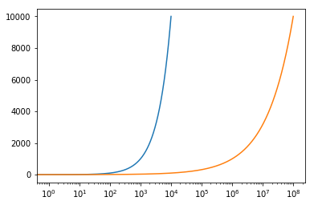

```python
x=np.arange(10000) # a list of 0 ... 9999
plt.plot(
    x,x,
    x**2,x
)
plt.xscale('log')    # use log scale for x axis
plt.show()
```

# Labels, Gridlines, etc.

We can use plotting commands (functions) to decorate our plots with x-labels, y-labels, gridlines, annotations, etc.

Each decoration can have styling properties for the text, lines, color fills, etc.

When all else fails, RTFM: https://matplotlib.org/api/pyplot_summary.html

# Extensions Libraries

## Extras that make Matplotlib really slick

https://matplotlib.org/thirdpartypackages/index.html

# Seaborn

Provides deeper integration with Pandas, NumPy, and Scipy to simplify plots from linear regression, clustering, time series, and other common analyses. It also adds much better default styling.

https://seaborn.pydata.org/

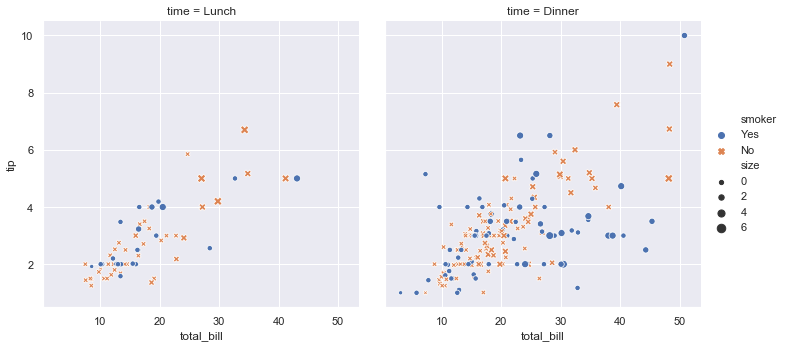

```python
# from the Seaborn intro ...
import seaborn as sns
sns.set()
tips = sns.load_dataset("tips") # a data set in the Seaborn repo
sns.relplot(x="total_bill", y="tip", col="time",
            hue="smoker", style="smoker", size="size",
            data=tips);
```

# Matplot3d

Provides 3D extensions of the basic plots. It is part of the Matplotlib package.

https://matplotlib.org/mpl_toolkits/mplot3d/

```python
#from the docs ...

import matplotlib as mpl
from mpl_toolkits.mplot3d import Axes3D # <--- this is it here
import numpy as np
import matplotlib.pyplot as plt
```

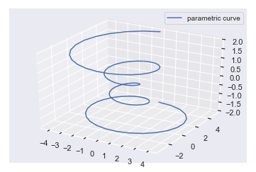

```python
mpl.rcParams['legend.fontsize'] = 10

fig = plt.figure()
ax = fig.gca(projection='3d')
theta = np.linspace(-4 * np.pi, 4 * np.pi, 100)
z = np.linspace(-2, 2, 100)
r = z**2 + 1
x = r * np.sin(theta)
y = r * np.cos(theta)
ax.plot(x, y, z, label='parametric curve')
ax.legend()
plt.show()
```

# Holoviews

Make plots into objects that can be recalled and shown in a variety of layouts. You can even overlay them if needed. Very handy for Jupyter notebooks.

http://holoviews.org/

# Bokeh

Bokeh is an interactive visualization library for things like dashboards. When combined with Matplotlib and pandas, it makes for a very powerful toolset.

https://bokeh.pydata.org

At its most basic usage, Bokeh can be used to export plots to HTML ...

```python
# from the docs ...

from bokeh.plotting import figure, output_file, show

# prepare some data
x = [1, 2, 3, 4, 5]
y = [6, 7, 2, 4, 5]

# output to static HTML file
output_file("lines.html")

# create a new plot with a title and axis labels
p = figure(title="simple line example", x_axis_label='x', y_axis_label='y')

# add a line renderer with legend and line thickness
p.line(x, y, legend="Temp.", line_width=2)

# show the results
show(p)
```

# Classwork (Start here in class)

- Course Schedule Part 4
- Health Stats Part 5
- Set up Final Project teams

# Homework (Do at home)

The following is due before class next week:

- Any remaining classwork from tonight
- Data Camp
  - "Importing Data with pandas" chapter
  - "pandas Foundations" course
- Study for Quiz 5 (A graded programming assignment)

Please email chuntley@fairfield.edu if you have any problems or questions.